# Aside

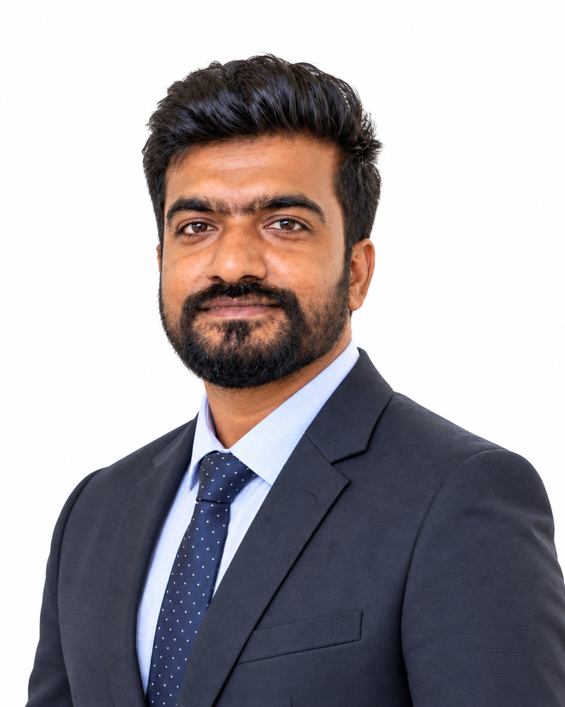

## Contact Info

- Assistant Professor
- [Galgotias College of Engineering & Technology (GCET)](https://galgotiacollege.edu/)
- Greater Noida, U.P. India
- prashantnag.workmail@gmail.com
- +91 7999459648
- www.prashantnag.com
- 0000-0002-1601-1455
- prashantnag
- prashantnag
- REku3NkAAAAJ
- 57408214000
- HPE-9262-2023
- ResearchInfuser

## Technical Skills

- *Advanced:* R (Quarto, Rmarkdown, etc.), Zotero, Python, WSL2/ Linux Workflow, DVC, Markdown, MS Office and Git
- *Intermediate:* Inkscape, Gimp, LibreOffice, PBS and bash/shell
- *Basic:* C/C++ and JavaScript

## Languages

- English: Professional Working Proficiency
- Hindi: Native

## Disclaimer

Last updated on 2026-10-24.

# Main

## Dr. Prashant Kumar Nag

### Curriculum Vitæ

I am an Assistant Professor and researcher specializing in Artificial Intelligence, Deep Learning, Natural Language Processing, and Affective Computing. My research focuses on emotion detection, cognitive appraisal, explainable AI, and healthcare text analytics, with an emphasis on developing intelligent, interpretable, and human-centered AI systems. I have experience in designing deep learning models for emotion recognition, conducting interdisciplinary research, and publishing in reputed journals and conferences. Alongside research, I am actively engaged in teaching, curriculum development, student mentoring, and academic administration. I am committed to advancing rigorous, reproducible, and impactful AI research while fostering innovation, collaboration, and excellence in higher education.

## Research Interests

### Affective Computing

N/A

N/A

Core

Computational emotion modeling, appraisal-based emotion reasoning, and human–AI affective interaction

### Text-based Emotion Recognition

N/A

N/A

Core

Sentence-, span-, and context-level models for emotion and emotion-cause detection

### Explainable AI for NLP

N/A

N/A

Methods

Attention-based interpretability, attribution techniques, and rule-based cognitive explanations for deep NLP models

## Education

### Doctor of Philosophy (Ph.D.) in Computer Applications

Maulana Azad National Institute of Technology, Bhopal

M.P. India

Jul. 2019 - Jun. 2026

**Thesis:** *Design of Efficient Artificial Intelligent Deep Learning Models for Human Emotion Detection*  
**Specialization:** *Artificial Intelligence, Deep Learning, Natural Language Processing and Affective Computing*  
**Supervisor:** Dr. Amit Bhagat  
**Co-supervisor:** Dr. R. Vishnu Priya

### Master of Computer Applications (MCA)

National Institute of Technology, Tiruchirappalli

T. N. India

Jul. 2012 - Jul. 2015

**Thesis:** *QR Code–Based Automated Attendance System for Classrooms*

### Bachelor of Computer Applications (BCA)

Devi Ahilya Vishwavidyalaya, Indore

M.P. India

Jul. 2008 - Aug. 2011

## TEACHING EXPERIENCE (4+ Years)

### Assistant Professor - Computer Applications

Galgotias College of Engineering & Technology, Greater Noida

U.P. India

Dec. 2025 - Present

*Postgraduate teaching in MCA program, including lectures, practical sessions, assessments, project supervision, and examination duties. Serving as Departmental Training & Placement Coordinator and CPDD Coordinator, coordinating placement activities, student training, industry interactions, skill development programs, internships, academic administration, student mentoring, and departmental quality initiatives.*

*Courses Taught*

[Web Technology (2026)](https://webtech2026.classes.prashantnag.com/)

[FCET (2026)](https://fcet2026.classes.prashantnag.com/)

### Faculty - Computer Science

Institute for Excellence in Higher Education, Bhopal

M.P. India

Aug. 2016 - Apr. 2019

*Undergraduate Computer Science teaching across multiple academic sessions, delivering lectures, supervised practicals, conducting evaluations, and mentoring students. Completed a total of **1,948** lectures between **2016 and 2019** as part of continuous teaching engagement.*

*Courses Taught*

Intro. to Programming (2016; 2017; 2018)

Linux Programming (2016; 2017;2018)

Computer Networks (2018;2019)

### Computer Faculty - Computer Applications

Unique Girls College Parasia, Chhindwara

M.P. India

Apr. 2016 - Jun. 2016

*Undergraduate teaching in Computer Applications, including practical supervision, evaluations, and student academic support.*

*Courses Taught*

Intro. to Programming (2016)

Computer Fundamentals (2016)

Internet and Web Design (2016)

### Assistant Professor - Computer Science

Sony College of Mgmt. and Technology, Chhindwara

M.P. India

Nov. 2015 - Apr. 2016

*Undergraduate and postgraduate teaching in Computer Science; responsible for lectures, practical sessions, assessments, and examination duties.*

*Courses Taught*

Intro. to Programming (2016)

Data Structures (2016)

Linux Programming (2016)

## Publications

### Publication Summary

**9** as first/corresponding or co-first authors, **1** as co-author

N/A

N/A

## Journal Articles

### Expanding AI’s Role in Healthcare Applications: A Systematic Review of Emotional and Cognitive Analysis Techniques

Prashant Kumar Nag, Amit Bhagat, R. Vishnu Priya

N/A

Apr. 2025

*IEEE Access*

SCIE • Q1 • IF 3.6 (JCR 2023)

[Read](https://doi.org/10.1109/ACCESS.2025.3562131)

### Yolov5-Based Attention Mechanism for Gesture Recognition in Complex Environment

Deepak Kumar Khare, Amit Bhagat, R. Vishnu Priya, Prashant Kumar Nag, Sunil Malviya

N/A

Nov. 2024

*International Journal of Advanced Computer Science & Applications*

Scopus • Q3 • IF 0.9 (2024)

[Read](https://doi.org/10.14569/ijacsa.2024.0151167)

### Text-Based Emotion Recognition Using Contextual Phrase Embedding Model

Vishnu Priya R., Prashant Kumar Nag

N/A

Sep. 2023

*Multimedia Tools and Applications*

SCIE • Q1 • IF 3.0 (JCR 2023)

[Read](https://doi.org/10.1007/s11042-023-14524-9)

## Conference Papers

### Leveraging Text Data in Healthcare: A Systematic Review of AI-Driven Emotional Analysis and Patient-Centric Innovations

Prashant Kumar Nag, Amit Bhagat, R Vishnu Priya, Sunil Malviya, Sanjay Mishra

N/A

Mar. 2026

*International Conference on Healthcare Innovation and Smart Systems (ICHISS 2024) (Conference Presentation)*

*AIP Conference Proceedings*

[Read](https://doi.org/10.1063/5.0322638)

### Emotional Intelligence Through Artificial Intelligence: NLP and Deep Learning in the Analysis of Healthcare Texts

Prashant Kumar Nag, Amit Bhagat, R. Vishnu Priya, Deepak Kumar Khare

N/A

Dec. 2023

*2023 International Conference on Artificial Intelligence for Innovations in Healthcare Industries (ICAIIHI) (Conference Presentation)*

*IEEE Xplore*

[Read](https://doi.org/10.1109/ICAIIHI57871.2023.10489117)

### Contextual BI-Directional Attention Flow With Embeddings From Language Models: A Generative Approach to Emotion Detection

Prashant Kumar Nag, Vishnu Priya R

N/A

Jun. 2021

*AIR ’21: Proceedings of the 2021 5<sup>*th*</sup> International Conference on Advances in Robotics (Conference Presentation)*

*ACM*

[Read](https://doi.org/10.1145/3478586.3478629)

## Preprints

### Advancing Patient Care through Text Data: A Systematic Review of AI, Emotional Analysis, and Patient-Centric Applications in Healthcare

Prashant Kumar Nag, Amit Bhagat, R Vishnu Priya

N/A

Jul. 2024

*TechRxiv*

[Read](https://doi.org/10.36227/techrxiv.172226053.36460987/v1)

### Emotional Intelligence Through Artificial Intelligence : NLP and Deep Learning in the Analysis of Healthcare Texts

Prashant Kumar Nag

N/A

Mar. 2024

*arXiv*

[Read](https://doi.org/10.48550/arXiv.2403.09762)

### A Systematic Review of AI, Emotional Analysis, and Patient-Centric Applications in Healthcare

Prashant Kumar Nag, Amit Bhagat, R Vishnu Priya

N/A

Dec. 2024

*TechRxiv*

[Read](https://doi.org/10.36227/techrxiv.172226053.36460987/v2)

## Other Publications

### Impact of Digitization on Indian Economy

Prashant Kumar Nag

N/A

Mar. 2018

*2<sup>*nd*</sup> National Conference on “Digital Economy: Impact and Challenges” (Conference Presentation)*

*IEHE Bhopal*

## Awards & Achievements

### National Fellowship for Scheduled Caste Students (2020-21)

National Testing Agency

India

Jun. 2020

*Awarded by the Ministry of Social Justice and Empowerment, Government of India.*

*National Fellowship*

### Entrance Examination for Full-Time Ph.D. (with Institute TA)

Maulana Azad National Institute of Technology

Bhopal, M.P.

Jun. 2019

*Qualified the MANIT Ph.D. Entrance Test (2019) and was selected for the Full-Time Ph.D. programme with Institute Teaching Assistantship (TA).*

*Entrance / Competitive Examination*

### National Eligibility Test for Assistant Professor

National Testing Agency / University Grants Commission

N/A

N/A

*Qualified for Assistant Professor*

**Jun. 2020 (53.33%)** **Dec. 2019 (46.67%)** **Jun. 2019 (50.00%)** **Dec. 2015 (53.71%)**

*Eligibility Examination (UGC–NET)*

### MCA Entrance Examinations

Cleared National Level MCA Entrance Exams

N/A

N/A

**IIT JAM (2011)** **JNU MCA (2011)** **NIMCET (2011, 2012)** **BIT MCA (2011)**: *AIR 17* **KIITEE MCA (2011)**: *Rank 15 (SC)*

*Entrance / Competitive Examinations*

## Invited Academic Engagements

### Speaker – Faculty Seminar Series

Department of Computer Applications (GCET)

Greater Noida, U.P.

Jun. 2026

Topic: *Modern Research Workflow for Academics, Literature Management, Scientific Writing, and Publication*

*Faculty Seminar*

### Invited Resource Person – Microsoft Office Suite Training

Acharyapuram Agri Business Management School (ABMS)

Greater Noida, U.P.

May. 2026

Topic: *Microsoft Office Suite (Word, Excel, PowerPoint, Gmail & Productivity Tools): Basic to Moderate Level with Hands-on Practical Sessions*

*Professional Training Program*

### Resource Person – Question Bank Development Workshop

Department of Physics & Electronics (IEHE)

Bhopal, M.P.

Oct. 2023

Topic: *Workshop on Question Bank Development and Outcome-Based Assessment Design*

*Workshop*

### Resource Person – National Workshop

Institute for Excellence in Higher Education (IEHE)

Bhopal, M.P.

Feb. 2022

Topic: *Computation Through Scilab & Solving differential Equations*

*National Workshop*

### Resource Person – AICTE ATAL FDP

Dept. of Mathematics, Bioinformatics and Computer Applications

Bhopal, M.P.

Nov. 2019

Topic: *Introduction to Virtual Reality: Concepts, Applications, and Future Trends*

*National FDP*

### Resource Person – AICTE ATAL FDP

Dept. of Mathematics, Bioinformatics and Computer Applications

Bhopal, M.P.

Sep. 2019

Topic: *Fundamentals of Naive Bayes Classification and Its Applications in Machine Learning*

*National FDP*

### Resource Person – Certificate Course in Cryptography

Institute for Excellence in Higher Education (IEHE)

Bhopal, M.P.

Aug. 2018

Topic: *Foundation Course on Cryptography: Principles, Algorithms, and Applications*

*Vocational Certificate Course*

### Resource Person – Cloud Computing and Digital Collaboration Tools

RCVP Noronha Academy

Bhopal, M.P.

Feb. 2018

Topic: *Practical Use of Google Drive, Skype, and Cloud-Based Collaboration Tools for Educators*

*Training Program*

### Resource Person – Moodle Learning Management System

NPTL Local Chapter & ICT Cell, IEHE

Bhopal, M.P.

Jan. 2018

Topic: *Hands-On Workshop on Configuring and Using Moodle for Online Teaching and Assessment*

*National Workshop*

## Workshops & Seminars

### IEEE Authorship and Open Access Symposium

IEEE

Online

Sep. 2025

*International Symposium*

### Workshop on Artificial Intelligence and High-Performance Computing

NIT Mizoram & IIT Kharagpur

Online

Jul. 2022

*National Workshop*

### Six-Day Student Excellence and Learning Program (NPIU-SELP)

TEQIP-III at MANIT

Bhopal, M.P.

Mar. 2020

*National Workshop*

### AICTE Training and Learning (ATAL) Academy Five-Day Workshop

Dept. of Electronics and Communication Engineering, MANIT

Online

Dec. 2019

*National Workshop*

### NPTEL Awareness Workshop and Online Learning

NPTEL Local Chapter & ICT Cell, IEHE

Bhopal, M.P.

Jan. 2018

*National Workshop*

### National Seminar on Emerging Trends in CS and IT (ETCSIT)

Department of Computer Science, IEHE

Bhopal, M.P.

Feb. 2017

*National Seminar*

## Professional Development

### AICTE Training And Learning (ATAL) Academy FDP on “Augmented Reality (AR)/Virtual Reality (VR)”

Department of MBC, MANIT

Bhopal M.P.

Nov. 2019

*National FDP*

### AICTE Training And Learning (ATAL) Academy FDP on “Internet of Things (IoT)”

Department of MBC, MANIT

Bhopal M.P.

Sep. 2019

*National FDP*

### Faculty Induction Programme (FIP) under TLC Project

NITTTR

Bhopal M.P.

May. 2019

*National FDP*

### Faculty Development Programme on Innovative Teaching Methodologies in the Present Context

Department of Computer Science, IEHE

Bhopal M.P.

Sep. 2016

*National FDP*

## Academic Service & Leadership

## Academic Administration & Coordination

### Research & Development Cell / Conference

Department of Computer Applications, GCET

Greater Noida, UP

Jul. 2026 - Present

*Assisting in the coordination of departmental research activities, conferences, workshops, and academic events.*

*Co-Coordinator*

### Intellectual Property Rights (IPR) Cell

Department of Computer Applications, GCET

Greater Noida, UP

Jul. 2026 - Present

*Coordinating departmental activities related to intellectual property rights, innovation, and IP awareness.*

*Coordinator*

### Education, Employability & Skill Development

Department of Computer Applications, GCET

Greater Noida, UP

Jul. 2026 - Present

*Coordinating departmental initiatives related to student employability, skill development, and career readiness.*

*Coordinator*

### Cyber Security, Cloud & Emerging Technologies Module

Department of Computer Applications, GCET

Greater Noida, UP

May. 2026 - Present

*Leading academic coordination of curriculum delivery, faculty collaboration, laboratories, projects, industry engagement, OBE implementation, and accreditation support for the assigned module.*

*Module Coordinator*

### Institute Training & Placement Committee

Galgotias College of Engineering & Technology

Greater Noida, UP

Jan. 2026 - Present

*Serving as a member of the institute-level Training & Placement Committee, supporting institutional placement planning, industry engagement, and coordination of placement-related initiatives.*

*Member*

### Major/Minor Project Coordinator

Department of Computer Applications, GCET

Greater Noida, UP

Dec. 2025 - Present

*Coordinating project allocation, progress monitoring, evaluation scheduling, and project documentation for MCA students.*

*Project Coordinator*

### Department Academic Timetable Management

Department of Computer Applications, GCET

Greater Noida, UP

Dec. 2025 - Present

*Assisting semester-wise timetable planning, faculty workload allocation, laboratory scheduling, and academic timetable management.*

*Time Table Co-Coordinator*

### Department Training & Placement Coordinator

Department of Computer Applications, GCET

Greater Noida, UP

Dec. 2025 - Present

*Coordinating departmental training, placement, career planning, internships, industry interaction, recruiter engagement, placement data management, and student employability initiatives.*

*Coordinator*

## Academic Technology & Digital Innovation

### Digital Course Website Development

Department of Computer Applications, GCET

Greater Noida, UP

Jan. 2026 - Jun. 2026

*Designed, developed, and maintained dedicated course websites to support postgraduate teaching through structured learning materials, laboratory manuals, assignments, project guidance, announcements, and self-paced learning resources, enhancing student engagement and digital learning.*

*Developer & Course Instructor*

### TechFest Promotional Teaser (IEHE)

ICT Cell, IEHE

Bhopal, MP

Dec. 2018

*Produced the inaugural promotional video for the departmental TechFest to support outreach and student engagement.*

*Media Designer*

### Moodle-Based Online Assignment Submission System

ICT Cell, IEHE

Bhopal, MP

Jan. 2017 - Dec. 2019

*Configured Moodle assignments and MCQ modules, prepared student databases, and trained faculty and ICT staff. Adopted by multiple academic departments for digital assessment.*

*Coordinator*

### Google Sites-Based Student Workflow System

ICT Cell, IEHE

Bhopal, MP

Jan. 2017 - Dec. 2019

*Designed and implemented Google Sites workflows for event registration, communication, schedules, and administrative coordination.*

*Coordinator*

## Quality Assurance & Accreditation

### NBA Accreditation Activities – Criterion 2

Department of Computer Applications, GCET

Greater Noida, UP

Dec. 2025 - Present

*Supporting NBA Criterion 2 documentation, data compilation, compliance reporting, and continuous quality improvement initiatives.*

*Co-Coordinator*

## Conference & Professional Service

### Students’ Conference on Electrical, Electronics and Computer Sciences (SCEECS 2025)

MANIT Student Branch

N/A

Dec. 2025

*Served as Meta Reviewer for the conference technical review process.*

*Meta Reviewer*

### 1<sup>*st*</sup> International Conference on Artificial Intelligence for Innovations in Healthcare Industries (ICAIIHI)

ICAIIHI Technical Program Committee

N/A

*Reviewed technical paper submissions for the international conference.*

*Reviewer*

### 4<sup>*th*</sup> IEEE International Conference on Signal Processing, Informatics, Communication and Energy Systems (IEEE SPICES 2024)

IIIT Kottayam

N/A

Dec. 2024

*Reviewed technical paper submissions for the international conference.*

*Reviewer*

### 7<sup>*th*</sup> International Conference on Recent Trends in Image Processing & Pattern Recognition (RTIP2R 2024)

IIIT Bhopal

N/A

Dec. 2024

*Reviewed technical paper submissions for the international conference.*

*Reviewer*

### Students’ Conference on Electrical, Electronics and Computer Sciences (SCEECS 2024)

MANIT Student Branch

N/A

Dec. 2024

*Served as Meta Reviewer for the conference technical review process.*

*Meta Reviewer*

### 6<sup>*th*</sup> International Conference on Communication and Intelligent Systems (ICCIS 2024)

Soft Computing Research Society

Bhopal, MP

Nov. 2024 - Nov. 2024

*Coordinated Technical Session TS04 – Emerging Techniques during the international conference.*

*Session Coordinator*

### TechFest (Computer Forum)

Department of Computer Science, IEHE

Bhopal, MP

Jan. 2017 - Dec. 2019

*Coordinated planning, student teams, publicity, logistics, and execution of departmental technical events.*

*Coordinator*

## Curriculum & Governance

### Board of Studies – Computer Science

Department of Computer Science, IEHE

Bhopal, MP

Jan. 2017 - Dec. 2019

*Contributed to curriculum review, syllabus restructuring, and academic policy discussions aligned with emerging trends in computer science and industry requirements.*

*Member*

## Open Source Projects

### MANIT Thesis Quarto Extension (manit-thesis)

Developer & Maintainer

N/A

2024

*Quarto extension that applies MANIT-approved thesis formatting through a reusable template for fully reproducible dissertation authoring.*

[GitHub](https://github.com/ResearchInfuser/manit-thesis)

### MANIT Presentation Template (manit-presentation)

Developer & Maintainer

N/A

2024

*Quarto presentation theme (reveal.js/beamer) aligned with MANIT branding, designed for research talks, conference presentations, and academic seminars with automated slide structuring, code highlighting, and reusable layouts.*

[GitHub](https://github.com/ResearchInfuser/manit-presentation)

### MANIT Pre-Thesis Template (manit-pre-thesis)

Developer & Maintainer

N/A

2024

*Quarto document template for MANIT PhD Pre-Thesis / Synopsis reports with standardized academic sections and automated formatting.*

[GitHub](https://github.com/ResearchInfuser/manit-pre-thesis)

## References

### Dr. Amit Bhagat

Associate Dean and Associate Professor, Department of Mathematics, Bioinformatics and Computer Applications  
Maulana Azad National Institute of Technology, Bhopal

M.P. India

am.bhagat@gmail.com  
amitbhagat@manit.ac.in  
+91 9827721214

### Dr. R. Vishnu Priya

Assistant Professor, Department of Computer Applications  
National Institute of Technology, Tiruchirappalli

T.N. India

vissaru@yahoo.co.in  
vishnupriya@nitt.edu  
+91 9486072557

### Dr. Dheeraj Kumar Dixit

Assistant Professor & Head, Department of Engineering Mathematics & Computing  
Madhav Institute of Technology and Science, Deemed University Gwalior (M.P.), India

M.P. India

dheerajdixit@mitsgwalior.in  
dheeraj.dixit26@gmail.com  
+91 8871932025